# Vulnerability Quick Analysis

```r
library(readr)

# Correct GitHub Raw URL
github_raw_url <- "https://raw.githubusercontent.com/auswallace/Vulnerably_Analysis/main/device_vuln_data_20250202_134935.csv"

# Read CSV with Explicit Column Types
df <- read_csv(github_raw_url, col_types = cols(
  device_id = col_character(),
  device_name = col_character(),
  ip_address = col_character(),
  os = col_character(),
  device_type = col_character(),
  scan_date = col_date(format = "%Y-%m-%d"),
  vulnerability_id = col_character(),
  cve_publish_date = col_date(format = "%Y-%m-%d"),
  plugin_id = col_double(),
  cvss_score = col_double(),
  risk_score = col_double(),
  exploit_available = col_character(),
  patch_available = col_character(),
  compliance_issue = col_character(),
  vulnerability_age = col_double()
))

head(df)
```

| device_id | device_name | ip_address | os | device_type | scan_date | vulnerability_id | cve_publish_date | plugin_id | cvss_score | risk_score | exploit_available | patch_available | compliance_issue | vulnerability_age |
| --- | --- | --- | --- | --- | --- | --- | --- | --- | --- | --- | --- | --- | --- | --- |
| DVC-10494 | host-931 | 192.168.133.64 | Linux RHEL | Server | 2024-08-14 | CVE-2018-98983 | 2023-09-17 | 90357 | 4.6 | 345 | No | Yes | Yes | 172 |
| DVC-10139 | host-885 | 192.168.147.15 | Linux Ubuntu | Workstation | 2024-03-12 | CVE-2017-71893 | 2023-01-15 | 78212 | 0.5 | 25 | Yes | Yes | No | 327 |
| DVC-10263 | host-591 | 192.168.222.23 | Linux RHEL | Server | 2024-08-26 | CVE-2024-49739 | 2023-06-04 | 13222 | 2.9 | 145 | Yes | Yes | No | 160 |
| DVC-10409 | host-974 | 192.168.86.110 | Linux RHEL | Server | 2024-08-27 | CVE-2020-16797 | 2023-03-14 | 26060 | 6.0 | 450 | Yes | No | No | 159 |
| DVC-10389 | host-785 | 192.168.181.72 | Linux RHEL | Server | 2024-06-18 | CVE-2020-94067 | 2023-09-24 | 19558 | 4.0 | 300 | No | No | No | 229 |
| DVC-10086 | host-841 | 192.168.50.41 | macOS Ventura | Workstation | 2024-09-27 | CVE-2020-58621 | 2023-08-22 | 52187 | 3.7 | 185 | Yes | No | No | 128 |

```r
# Basic summary statistics
summary(df)
```

```
##   device_id         device_name         ip_address             os
##  Length:5000        Length:5000        Length:5000        Length:5000
##  Class :character   Class :character   Class :character   Class :character
##  Mode  :character   Mode  :character   Mode  :character   Mode  :character
##
##
##
##  device_type          scan_date          vulnerability_id
##  Length:5000        Min.   :2024-01-01   Length:5000
##  Class :character   1st Qu.:2024-04-03   Class :character
##  Mode  :character   Median :2024-07-06   Mode  :character
##                     Mean   :2024-07-02
##                     3rd Qu.:2024-09-29
##                     Max.   :2024-12-31
##  cve_publish_date       plugin_id       cvss_score       risk_score
##  Min.   :2023-01-01   Min.   :10493   Min.   : 0.100   Min.   :   5.0
##  1st Qu.:2023-04-09   1st Qu.:31308   1st Qu.: 3.300   1st Qu.: 165.0
##  Median :2023-07-23   Median :55818   Median : 5.300   Median : 397.5
##  Mean   :2023-07-13   Mean   :53913   Mean   : 5.332   Mean   : 482.6
##  3rd Qu.:2023-10-11   3rd Qu.:74761   3rd Qu.: 7.800   3rd Qu.: 780.0
##  Max.   :2023-12-31   Max.   :99986   Max.   :10.000   Max.   :1250.0
##  exploit_available  patch_available    compliance_issue   vulnerability_age
##  Length:5000        Length:5000        Length:5000        Min.   : 33.0
##  Class :character   Class :character   Class :character   1st Qu.:126.0
##  Mode  :character   Mode  :character   Mode  :character   Median :211.0
##                                                           Mean   :214.7
##                                                           3rd Qu.:305.0
##                                                           Max.   :398.0
```

### Exploratory Data Analysis

#### Missing field check

```r
# Count missing values in each column
df %>%
  summarise(across(everything(), ~ sum(is.na(.)))) %>%
  pivot_longer(everything(), names_to = "column", values_to = "missing_count") %>%
  filter(missing_count > 0)
```

| column | missing_count |
| --- | --- |

#### Risk Score Distribution

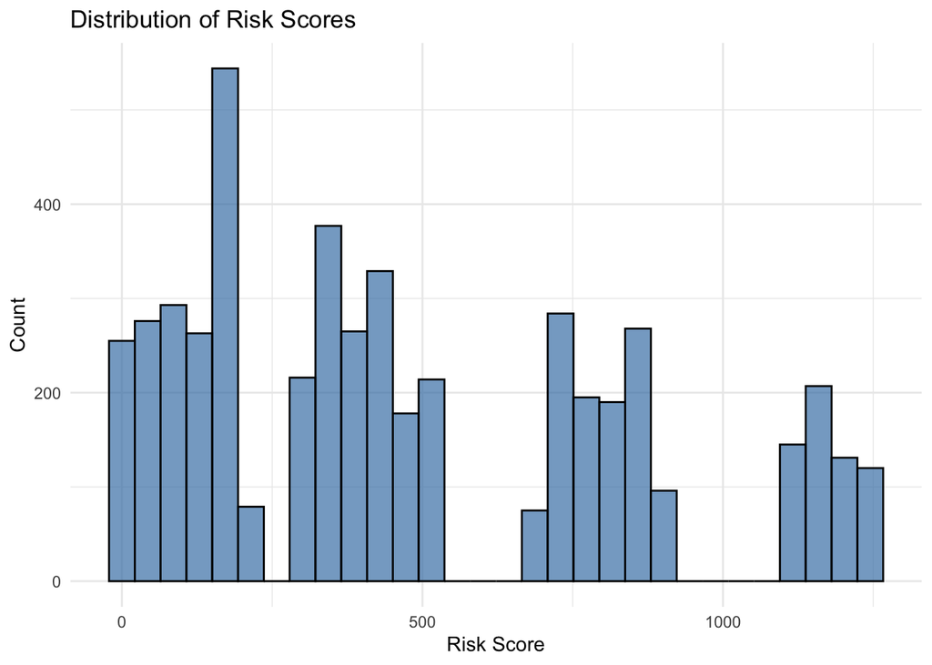

```r
# Histogram of risk scores
ggplot(df, aes(x = risk_score)) +
  geom_histogram(bins = 30, fill = "steelblue", color = "black", alpha = 0.7) +
  labs(title = "Distribution of Risk Scores", x = "Risk Score", y = "Count") +
  theme_minimal()
```

#### OS by Risk

- Identifies which OS versions are most vulnerable on average.
- Useful for prioritizing remediation by OS type.

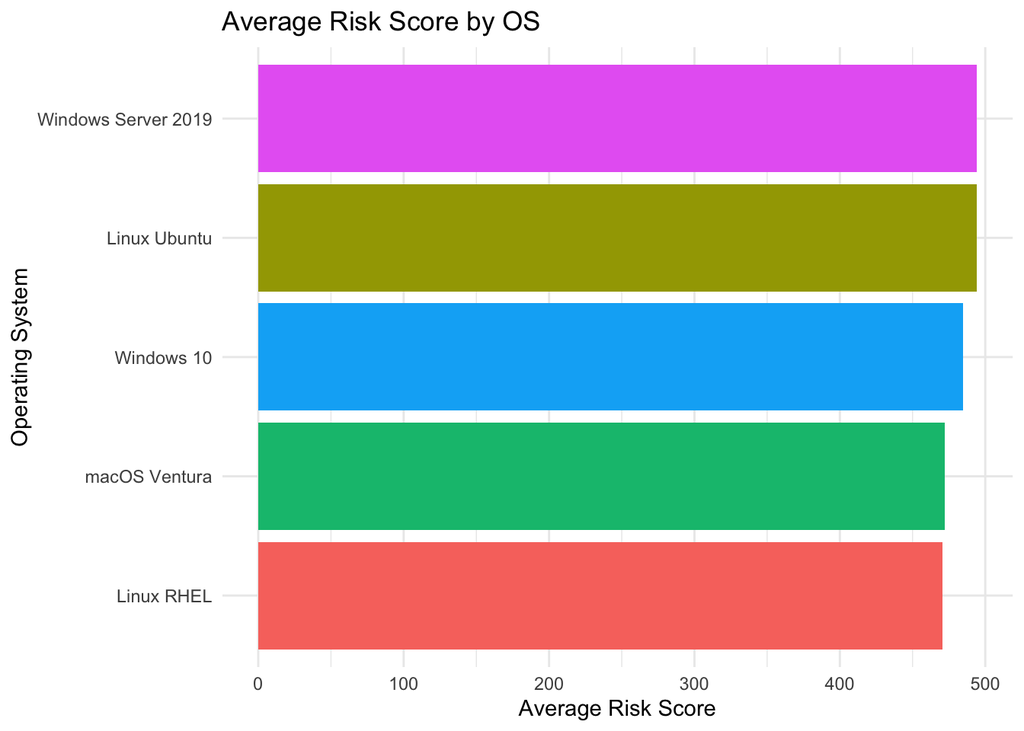

```r
# Average risk score per OS
df %>%
  group_by(os) %>%
  summarise(avg_risk = mean(risk_score, na.rm = TRUE), count = n()) %>%
  arrange(desc(avg_risk)) %>%
  ggplot(aes(x = reorder(os, avg_risk), y = avg_risk, fill = os)) +
  geom_col(show.legend = FALSE) +
  coord_flip() +
  labs(title = "Average Risk Score by OS", x = "Operating System", y = "Average Risk Score") +
  theme_minimal()
```

#### Patch Availability vs. Risk Score

- Do patched vulnerabilities tend to have lower risk scores?
- Could indicate whether patches are being applied effectively.

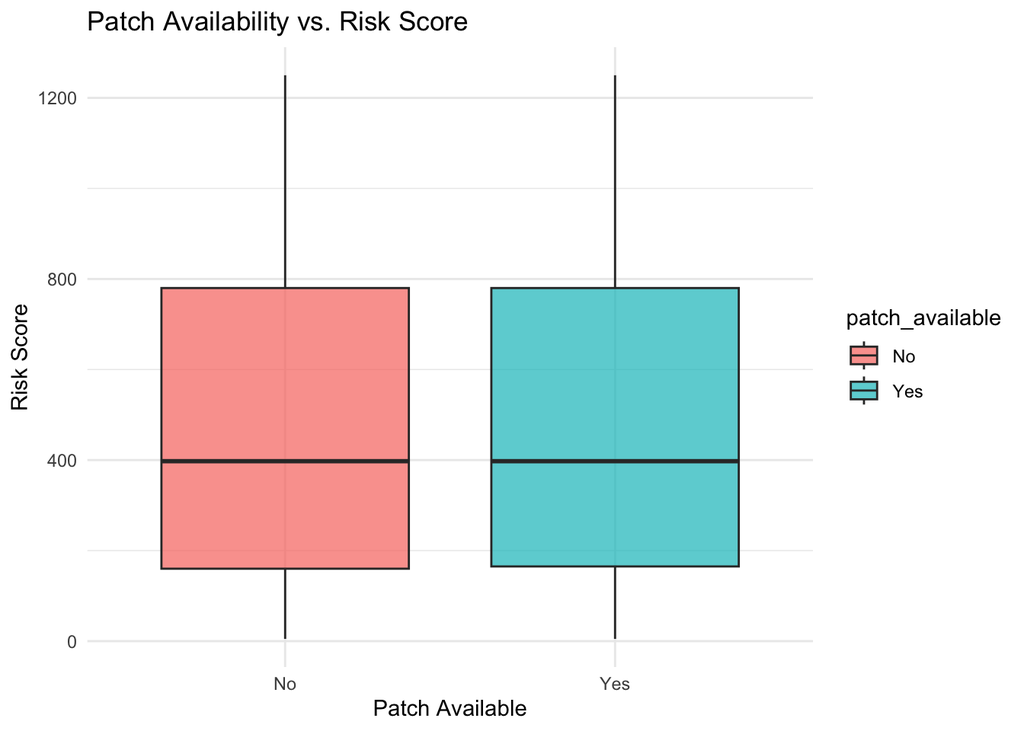

```r
ggplot(df, aes(x = patch_available, y = risk_score, fill = patch_available)) +
  geom_boxplot(alpha = 0.7) +
  labs(title = "Patch Availability vs. Risk Score", x = "Patch Available", y = "Risk Score") +
  theme_minimal()
```

#### CVSS Scores

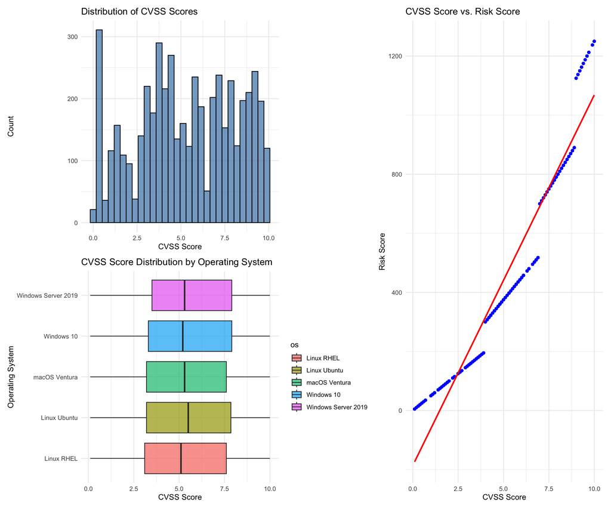

```r
# Load necessary libraries
library(ggplot2)
library(patchwork)  # For combining multiple plots

# Histogram of CVSS Scores
p1 <- ggplot(df, aes(x = cvss_score)) +
  geom_histogram(bins = 30, fill = "steelblue", color = "black", alpha = 0.7) +
  labs(title = "Distribution of CVSS Scores", x = "CVSS Score", y = "Count") +
  theme_minimal()

# Boxplot of CVSS Scores by OS
p2 <- ggplot(df, aes(x = os, y = cvss_score, fill = os)) +
  geom_boxplot(alpha = 0.7) +
  coord_flip() +
  labs(title = "CVSS Score Distribution by Operating System", x = "Operating System", y = "CVSS Score") +
  theme_minimal()

# Scatter Plot: CVSS vs. Risk Score
p3 <- ggplot(df, aes(x = cvss_score, y = risk_score)) +
  geom_point(alpha = 0.5, color = "blue") +
  geom_smooth(method = "lm", color = "red", se = FALSE) +
  labs(title = "CVSS Score vs. Risk Score", x = "CVSS Score", y = "Risk Score") +
  theme_minimal()

# Combine all plots using patchwork
(p1 / p2) | p3
```

### Analysis 1

#### Top 10 Most Pervasive Vulnerabilities

This will identify vulnerabilities that are:

Most frequently occurring (high count in dataset) Highest risk impact (based on total risk_score)

```r
library(dplyr)
library(gt)

# Aggregate by vulnerability ID
top_vulns <- df %>%
  group_by(vulnerability_id) %>%
  summarise(
    count = n(),
    avg_risk = mean(risk_score, na.rm = TRUE),
    total_risk = sum(risk_score, na.rm = TRUE)
  ) %>%
  arrange(desc(count), desc(total_risk)) %>%
  head(10)

# Format table using gt
top_vulns %>%
  gt() %>%
  tab_header(
    title = "Top 10 Most Pervasive Vulnerabilities",
    subtitle = "Ranked by Occurrence & Total Risk"
  ) %>%
  fmt_number(columns = c(avg_risk, total_risk), decimals = 2) %>%
  cols_label(
    vulnerability_id = "Vulnerability ID",
    count = "Occurrence Count",
    avg_risk = "Average Risk Score",
    total_risk = "Total Risk Score"
  )
```

Top 10 Most Pervasive Vulnerabilities

Ranked by Occurrence & Total Risk

| Vulnerability ID | Occurrence Count | Average Risk Score | Total Risk Score |
| --- | --- | --- | --- |
| CVE-2018-78131 | 33 | 700.00 | 23,100.00 |
| CVE-2016-25931 | 33 | 517.50 | 17,077.50 |
| CVE-2019-43640 | 33 | 510.00 | 16,830.00 |
| CVE-2015-16433 | 31 | 1,137.50 | 35,262.50 |
| CVE-2016-62977 | 30 | 322.50 | 9,675.00 |
| CVE-2017-4661 | 30 | 135.00 | 4,050.00 |
| CVE-2022-17293 | 30 | 135.00 | 4,050.00 |
| CVE-2015-89803 | 29 | 1,250.00 | 36,250.00 |
| CVE-2016-17353 | 29 | 457.50 | 13,267.50 |
| CVE-2020-64509 | 29 | 155.00 | 4,495.00 |

#### Top 10 Riskiest Workstations

```r
library(gt)

top_workstations %>%
  mutate(Rank = row_number()) %>%
  gt() %>%
  tab_header(
    title = "🔴 Top 10 Riskiest Workstations",
    subtitle = "Ranked by Total Risk Score"
  ) %>%
  fmt_number(columns = c(total_risk, avg_risk), decimals = 2)
```

🔴 Top 10 Riskiest Workstations

Ranked by Total Risk Score

| device_id | device_name | os | total_risk | avg_risk | vuln_count | Rank |
| --- | --- | --- | --- | --- | --- | --- |
| DVC-10293 | host-439 | Windows 10 | 10,262.50 | 684.17 | 15 | 1 |
| DVC-10090 | host-594 | Linux Ubuntu | 9,695.00 | 745.77 | 13 | 2 |
| DVC-10444 | host-755 | Windows 10 | 9,480.00 | 632.00 | 15 | 3 |
| DVC-10182 | host-677 | Linux Ubuntu | 9,452.50 | 630.17 | 15 | 4 |
| DVC-10425 | host-641 | Windows 10 | 9,175.00 | 539.71 | 17 | 5 |
| DVC-10462 | host-829 | macOS Ventura | 9,117.50 | 701.35 | 13 | 6 |
| DVC-10165 | host-437 | macOS Ventura | 8,987.50 | 473.03 | 19 | 7 |
| DVC-10275 | host-706 | macOS Ventura | 8,835.00 | 552.19 | 16 | 8 |
| DVC-10106 | host-911 | macOS Ventura | 8,832.50 | 630.89 | 14 | 9 |
| DVC-10153 | host-759 | macOS Ventura | 8,795.00 | 628.21 | 14 | 10 |

#### Top 10 Riskiest Servers

```r
library(gt)

top_servers %>%
  mutate(Rank = row_number()) %>%
  gt() %>%
  tab_header(
    title = "🔴 Top 10 Riskiest Servers",
    subtitle = "Ranked by Total Risk Score"
  ) %>%
  fmt_number(columns = c(total_risk, avg_risk), decimals = 2)
```

🔴 Top 10 Riskiest Servers

Ranked by Total Risk Score

| device_id | device_name | os | total_risk | avg_risk | vuln_count | Rank |
| --- | --- | --- | --- | --- | --- | --- |
| DVC-10476 | host-395 | Windows Server 2019 | 12,135.00 | 758.44 | 16 | 1 |
| DVC-10068 | host-640 | Windows Server 2019 | 9,927.50 | 709.11 | 14 | 2 |
| DVC-10335 | host-980 | Linux RHEL | 9,667.50 | 537.08 | 18 | 3 |
| DVC-10397 | host-733 | Windows Server 2019 | 9,590.00 | 639.33 | 15 | 4 |
| DVC-10185 | host-720 | Windows Server 2019 | 9,545.00 | 596.56 | 16 | 5 |
| DVC-10315 | host-798 | Windows Server 2019 | 9,112.50 | 650.89 | 14 | 6 |
| DVC-10451 | host-478 | Linux RHEL | 8,900.00 | 468.42 | 19 | 7 |
| DVC-10134 | host-953 | Linux RHEL | 8,862.50 | 633.04 | 14 | 8 |
| DVC-10301 | host-416 | Windows Server 2019 | 8,692.50 | 620.89 | 14 | 9 |
| DVC-10062 | host-628 | Linux RHEL | 8,570.00 | 714.17 | 12 | 10 |

###Analysis 2: Patch Effectiveness & Compliance Gaps

#### Key Questions:

- Are high-risk vulnerabilities being left unpatched?
- Do compliance issues correlate with longer vulnerability exposure?
- Which OS types or device categories have the worst patch adoption?
- How long does it take for vulnerabilities to be patched after discovery?

####1) Risk Scores vs. Patch Availability - Are Critical Vulns Being Patched Hypothesis: If high-risk vulnerabilities (CVSS 9+) are left unpatched, security posture is weak.

- Boxplot: risk_score vs. patch_available
- Statistical Test: Use Wilcoxon rank-sum test to check if patched vs. unpatched vulnerabilities have significantly different risk_score distributions.
- Actionable Insight: If unpatched vulnerabilities have higher risk, then remediation should focus on high-priority patches first.

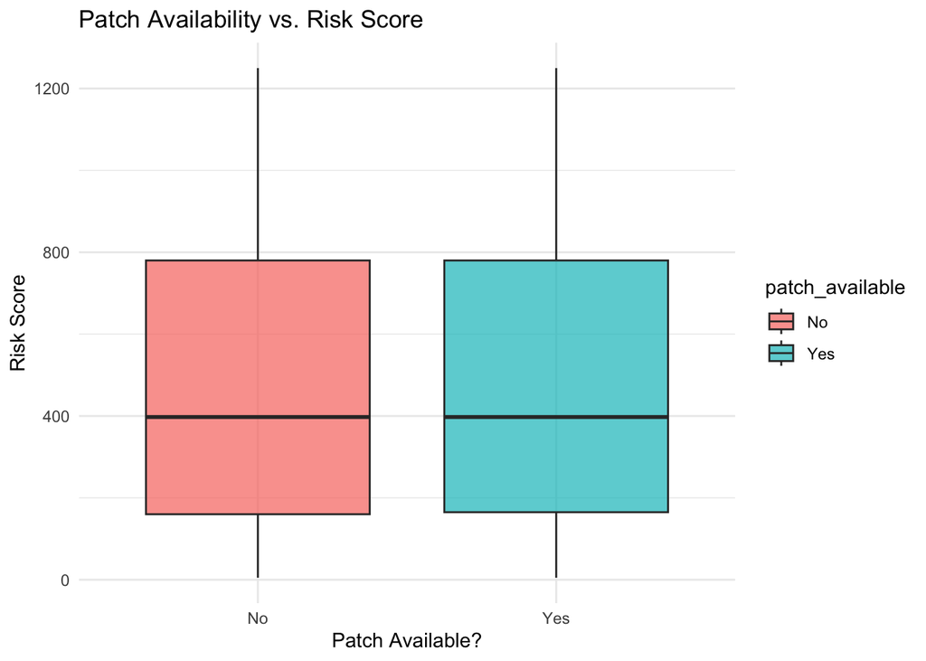

```r
# Boxplot of Risk Score vs. Patch Availability
ggplot(df, aes(x = patch_available, y = risk_score, fill = patch_available)) +
  geom_boxplot(alpha = 0.7) +
  labs(title = "Patch Availability vs. Risk Score", x = "Patch Available?", y = "Risk Score") +
  theme_minimal()
```

```r
# Wilcoxon Test: Are patched vulnerabilities significantly lower in risk?
wilcox.test(risk_score ~ patch_available, data = df)
```

```
##
##  Wilcoxon rank sum test with continuity correction
##
## data:  risk_score by patch_available
## W = 3160892, p-value = 0.4803
## alternative hypothesis: true location shift is not equal to 0
```

Since p = 0.4803 > 0.05, the test suggests that there isn’t a meaningful difference in risk scores between patched and unpatched vulnerabilities. - This means that patching does not seem to correlate with risk reduction in this dataset. - Possible explanations: - Patches may not be applied strategically (i.e., teams are patching low-risk vulnerabilities as often as high-risk ones). - High-risk vulnerabilities remain unpatched at the same rate as lower-risk ones. - Risk score calculation doesn’t factor in patching effectiveness.

#### Compliance Issues vs. Risk Score - Do Non-Compliant Devices Have Higher Risk?

🔍 Hypothesis: Non-compliant devices (security misconfigurations, missing controls) have higher risk scores.

- Boxplot: risk_score vs. compliance_issue
- Chi-Square Test: Check if non-compliant devices have more high-risk vulnerabilities
- Actionable Insight: If non-compliance is a strong predictor of risk, then compliance enforcement should be prioritized.

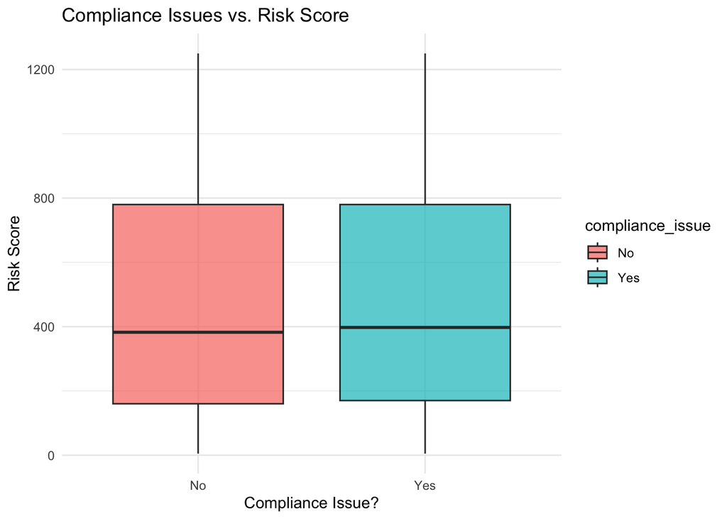

```r
# Boxplot of Compliance Issues vs. Risk Score
ggplot(df, aes(x = compliance_issue, y = risk_score, fill = compliance_issue)) +
  geom_boxplot(alpha = 0.7) +
  labs(title = "Compliance Issues vs. Risk Score", x = "Compliance Issue?", y = "Risk Score") +
  theme_minimal()
```

```r
# Chi-Square Test: Are compliance issues correlated with high risk?
table_compliance <- table(df$compliance_issue, df$risk_score > 500)
chisq.test(table_compliance)
```

```
##
##  Pearson's Chi-squared test with Yates' continuity correction
##
## data:  table_compliance
## X-squared = 0.63293, df = 1, p-value = 0.4263
```

Compliance issues do not appear to be a predictor of higher risk scores. - This suggests that both compliant and non-compliant devices have similar levels of risk in your dataset. - Possible explanations: - Compliance flags might not be capturing true security risk. - The definition of “compliance issue” might be too broad to show a clear relationship with risk. - Some compliant devices could still have high-risk vulnerabilities, and some non-compliant ones might be low-risk.

```r
library(survival)
library(survminer)
```

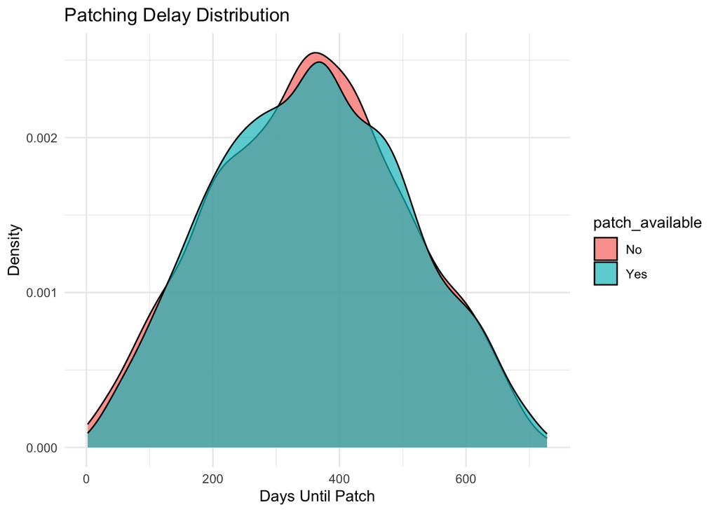

```r
# Calculate patching delay
df$patching_delay <- as.numeric(df$scan_date - df$cve_publish_date)

# Density Plot: How long does it take to patch vulnerabilities?
ggplot(df, aes(x = patching_delay, fill = patch_available)) +
  geom_density(alpha = 0.7) +
  labs(title = "Patching Delay Distribution", x = "Days Until Patch", y = "Density") +
  theme_minimal()
```

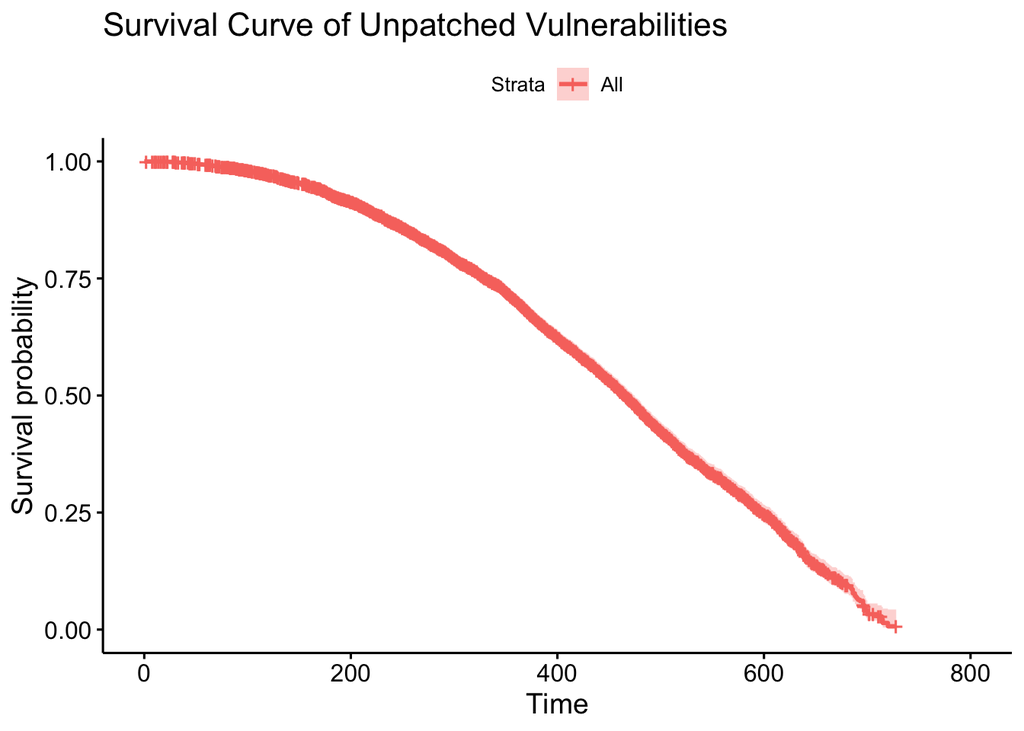

```r
# Survival Analysis: Probability of remaining unpatched over time
surv_obj <- Surv(df$patching_delay, df$patch_available == "Yes")
km_fit <- survfit(surv_obj ~ 1)
ggsurvplot(km_fit, data = df, title = "Survival Curve of Unpatched Vulnerabilities")
```

### Analysis 2: Risk Score Heatmap - Identifying High-Risk Device Clusters

Key Questions - Wich devices are most at risk based on cumulative risk score? - Are there clusters of high-risk devices that need immediate attention? - Are certain OS types or device groups contributing disproportionately to risk?

#### Heatmap of Risk Scores Across Devices & OS

Hypothesis: Certain OS types or devices have more critical vulnerabilities.

- Heatmap of risk_score by device_id & os
- Hierarchical Clustering: Identify groups of high-risk devices
- Actionable Insight: If specific OS types dominate risk, security teams should prioritize those for patching.

```r
library(reshape2)
# Aggregate risk scores per device
risk_matrix <- df %>%
  group_by(device_id, os) %>%
  summarise(total_risk = sum(risk_score, na.rm = TRUE)) %>%
  acast(device_id ~ os, value.var = "total_risk", fill = 0)
```

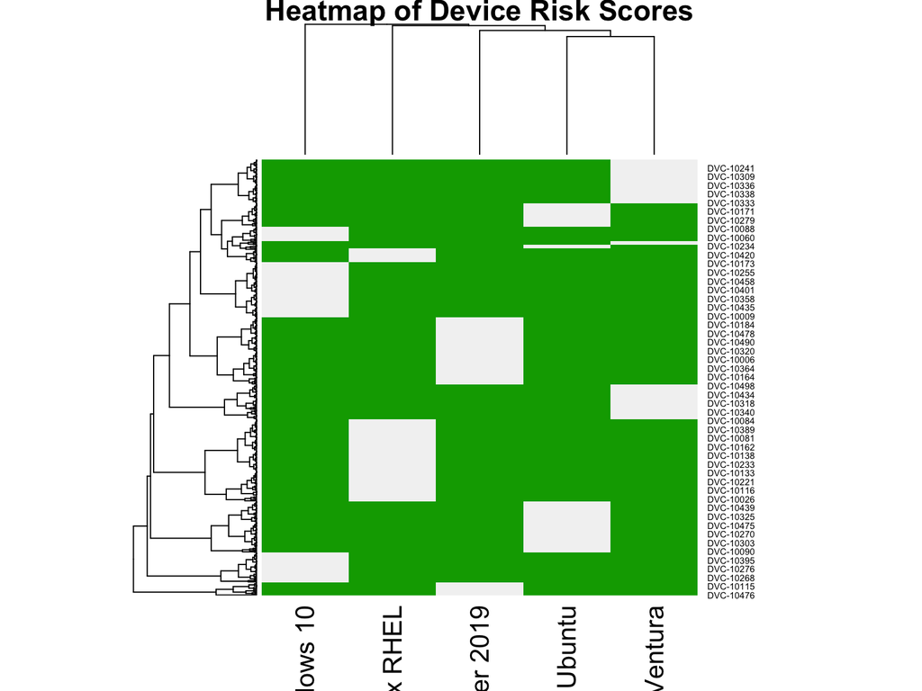

```r
# Heatmap of risk scores by device and OS
heatmap(risk_matrix, scale = "row", col = terrain.colors(10), main = "Heatmap of Device Risk Scores")
```

#### Clustering Devices by Risk Level

🔍 Hypothesis: Some devices are persistently high-risk and should be isolated or prioritized.

- Use K-Means Clustering to segment devices into low, medium, and high risk
- Visualize Clusters: Scatter plot with kmeans() labels
- Actionable Insight: If certain clusters have high-risk servers, isolate or segment them.

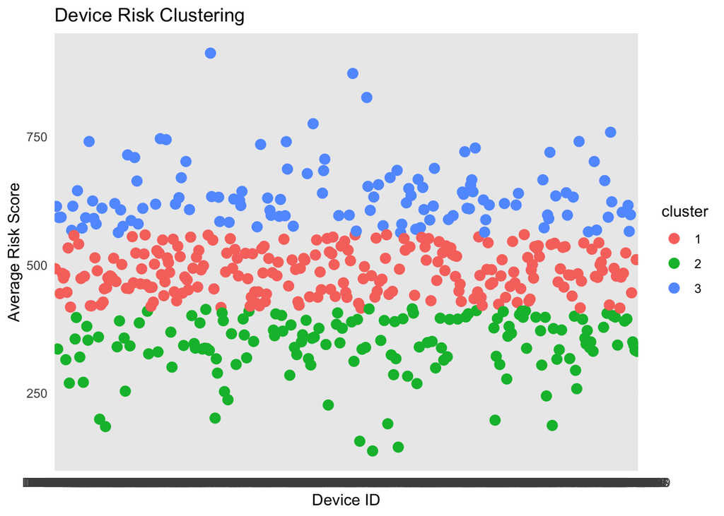

```r
# Prepare data for clustering
df_cluster <- df %>%
  group_by(device_id) %>%
  summarise(avg_risk = mean(risk_score, na.rm = TRUE))

# Apply K-Means clustering
set.seed(42)
kmeans_result <- kmeans(df_cluster$avg_risk, centers = 3)

# Scatter Plot of Clusters
df_cluster$cluster <- as.factor(kmeans_result$cluster)
ggplot(df_cluster, aes(x = device_id, y = avg_risk, color = cluster)) +
  geom_point(size = 3) +
  labs(title = "Device Risk Clustering", x = "Device ID", y = "Average Risk Score") +
  theme_minimal()
```